# Notebook 2 (Extended) — Pseudobulk DE & GO Analysis (Solutions)

CAJAL Neuromics 2026 · Spinal Cord Injury

```r
library(Seurat)
library(edgeR)
library(ggplot2)
library(dplyr)
library(patchwork)
library(clusterProfiler)
library(org.Mm.eg.db)
library(splatter)
library(sparseMatrixStats)
library(lme4)
library(lmerTest)

PROJ_DIR <- "/shared/projects/tp_2630_ubordeaux_neuromics_184418/projects/C14/"
DATA_DIR <- file.path(PROJ_DIR, "data")
FIG_DIR  <- file.path(PROJ_DIR, "figures")
GIT_DIR  <- "~/cajal-project-alan"
source(file.path(GIT_DIR, "setup-quarto-visualization.R"))
```

```
httpgd server running at:
  http://127.0.0.1:41747/live?token=H8gzVedS
```

```r
sci_sub = readRDS(file.path(DATA_DIR, "sci-subset-atlas-annotated.rds"))
sci_sub$cell_type = sci_sub$layer2
```

## From composition change to cell-type-specific DE

In Notebook 1, you showed that spinal cord injury shifts the **composition** of cell types. But composition change is only one half of the story. The other half: **within each cell type, which genes change?**

A gene driving microglial activation is biologically distinct from one driving astrocyte reactivity — even if both appear as “upregulated in injured tissue” in a bulk experiment. Single-cell resolution lets us separate these signals.

The most natural starting point is Seurat’s built-in `FindMarkers`, which applies a Wilcoxon rank-sum test cell by cell. Let’s try it first.

## 1. Seurat Wilcoxon test

`FindMarkers` is Seurat’s default DE function. It tests each gene using a Wilcoxon rank-sum test, treating every cell as an independent observation.

```r
mg = sci_sub[, sci_sub$cell_type == "Microglia" & sci_sub$label %in% c("young", "uninjured")]
mg = NormalizeData(mg)
```

```
Normalizing layer: counts
```

```r
Idents(mg) = mg$label
```

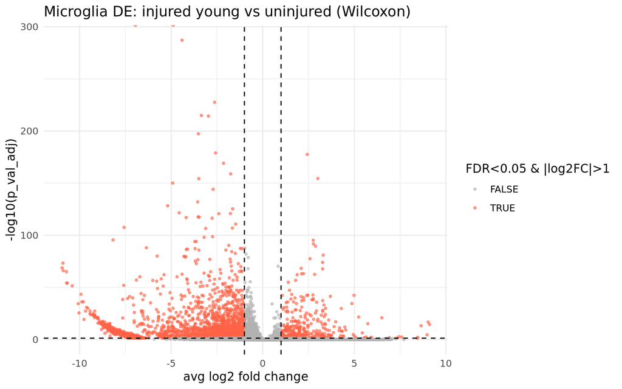

```r
markers_wilcox = FindMarkers(
    mg,
    ident.1 = "young",
    ident.2 = "uninjured",
    test.use = "wilcox",
    logfc.threshold = 0,
    min.pct = 0.01
)
markers_wilcox$gene = rownames(markers_wilcox)
markers_wilcox$sig = markers_wilcox$p_val_adj < 0.05 & abs(markers_wilcox$avg_log2FC) > 1

ggplot(markers_wilcox, aes(x = avg_log2FC, y = -log10(p_val_adj), colour = sig)) +
    geom_point(alpha = 0.6, size = 0.8) +
    scale_colour_manual(values = c("grey70", "tomato")) +
    geom_vline(xintercept = c(-1, 1), linetype = "dashed") +
    geom_hline(yintercept = -log10(0.05), linetype = "dashed") +
    theme_minimal() +
    labs(
        title = "Microglia DE: injured young vs uninjured (Wilcoxon)",
        x = "avg log2 fold change", colour = "FDR<0.05 & |log2FC|>1"
    )
```

```r
cat("Significant genes (Wilcoxon):", sum(markers_wilcox$sig, na.rm = TRUE), "\n")
```

```
Significant genes (Wilcoxon): 2262
```

**Interpret:** How many genes are called significant? Does this number seem plausible given what you know about microglial activation after injury?

## 2. The problem with cell-level tests

The number of significant genes in section 1 looks high. Is it real, or is the test calling too many? We can answer this directly using simulated data where we control the ground truth — we know exactly which genes are truly DE and which are not.

We generate two scenarios:

- **Null**: no DE genes at all (`de_prob = 0`) — any significant hit is a false positive
- **DE**: 10% of genes are truly DE (`de_prob = 0.1`) — we can compare discovered genes against the known truth

```r
set.seed(42)
sim_null = simulate_counts(n_genes = 1000, n_cells = 500, de_prob = 0, n_samples = 6)
sim_de = simulate_counts(n_genes = 1000, n_cells = 500, de_prob = 0.1, de_fc = 2, n_samples = 6)
```

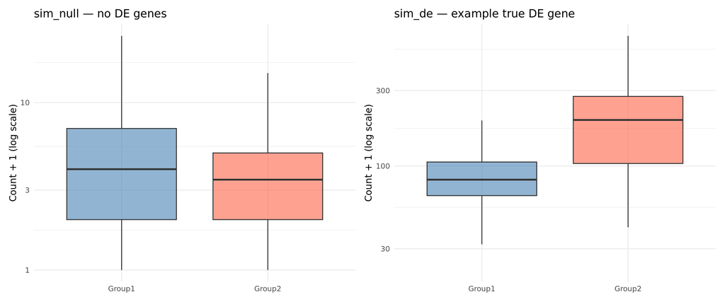

```r
null_df = data.frame(
    expr = as.numeric(sim_null$counts[rownames(sim_null$counts)[1], ]),
    label = sim_null$metadata$label,
    replicate = sim_null$metadata$replicate
)
p_null = ggplot(null_df, aes(x = label, y = expr + 1, fill = label)) +
    geom_boxplot(outlier.shape = NA, alpha = 0.6) +
    scale_y_log10() +
    scale_fill_manual(values = c("steelblue", "tomato")) +
    labs(title = "sim_null — no DE genes", y = "Count + 1 (log scale)", x = NULL) +
    theme_minimal() +
    theme(legend.position = "none")

de_df = data.frame(
    expr = as.numeric(sim_de$counts[sim_de$de_genes[1], ]),
    label = sim_de$metadata$label,
    replicate = sim_de$metadata$replicate
)
p_de = ggplot(de_df, aes(x = label, y = expr + 1, fill = label)) +
    geom_boxplot(outlier.shape = NA, alpha = 0.6) +
    scale_y_log10() +
    scale_fill_manual(values = c("steelblue", "tomato")) +
    labs(title = "sim_de — example true DE gene", y = "Count + 1 (log scale)", x = NULL) +
    theme_minimal() +
    theme(legend.position = "none")

p_null + p_de
```

Now run the Wilcoxon test cell-by-cell on both simulations:

```r
so_null = CreateSeuratObject(counts = sim_null$counts, meta.data = sim_null$metadata)
so_null$cell_type = "Simulated"
so_null = NormalizeData(so_null)
```

```
Normalizing layer: counts
```

```r
Idents(so_null) = so_null$label
res_null = FindMarkers(so_null, ident.1 = "Group1", ident.2 = "Group2",
    test.use = "wilcox", logfc.threshold = 0, min.pct = 0)
padj_null = setNames(res_null$p_val_adj, rownames(res_null))

so_de = CreateSeuratObject(counts = sim_de$counts, meta.data = sim_de$metadata)
so_de$cell_type = "Simulated"
so_de = NormalizeData(so_de)
```

```
Normalizing layer: counts
```

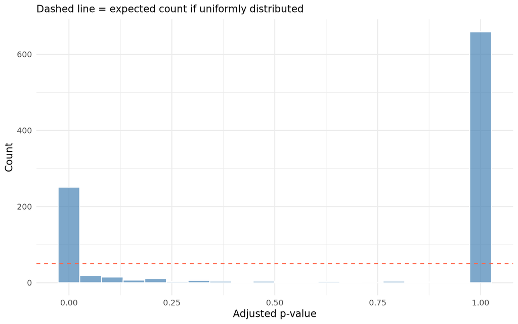

```r
Idents(so_de) = so_de$label
res_de = FindMarkers(so_de, ident.1 = "Group1", ident.2 = "Group2",
    test.use = "wilcox", logfc.threshold = 0, min.pct = 0)
padj_de = setNames(res_de$p_val_adj, rownames(res_de))

# p-value distribution under the null — should be uniform if the test is well-calibrated
pval_df = data.frame(p = padj_null, scenario = "Null (de_prob = 0)")
ggplot(pval_df, aes(x = p)) +
    geom_histogram(bins = 20, fill = "steelblue", colour = "white", alpha = 0.7) +
    geom_hline(yintercept = 1000 / 20, linetype = "dashed", colour = "tomato") +
    labs(x = "Adjusted p-value", y = "Count",
         subtitle = "Dashed line = expected count if uniformly distributed") +
    theme_minimal()
```

```r
cat("False discoveries under null (FDR < 0.05):", sum(padj_null < 0.05), "/ 1000 genes\n")
```

```
False discoveries under null (FDR < 0.05): 261 / 1000 genes
```

```r
# DE simulation: realized FDR vs nominal 5%
sig_genes_de = names(padj_de)[padj_de < 0.05]
n_sig = length(sig_genes_de)
n_fp = sum(!sig_genes_de %in% sim_de$de_genes)
cat("Significant genes (Wilcoxon):", n_sig, "\n")
```

```
Significant genes (Wilcoxon): 321
```

```r
cat("True positives:", n_sig - n_fp, "/", length(sim_de$de_genes), "truly DE genes\n")
```

```
True positives: 80 / 100 truly DE genes
```

```r
cat("False positives:", n_fp, "\n")
```

```
False positives: 241
```

```r
cat("Realized FDR:", round(n_fp / n_sig, 3), "(nominal = 0.05)\n")
```

```
Realized FDR: 0.751 (nominal = 0.05)
```

**Interpret:** How many false discoveries does the Wilcoxon produce under the null? How does the number of significant genes in the DE simulation compare to the true number of DE genes?

The reason: cells from the same animal share a common random effect on expression. Treating them as independent observations inflates the effective sample size, deflates p-values, and produces far too many significant hits. The correct unit of replication is the **biological replicate** (animal), not the cell. The fix is to aggregate counts per replicate before testing — **pseudobulk**.

## 3. Pseudobulk aggregation

Pseudobulk collapses all cells from the same cell type and replicate into a single count vector by summing raw counts. This gives one “sample” per (cell type × replicate) combination — exactly the input a bulk DE method like edgeR expects.

```r
make_pseudobulk = function(seurat_obj, cell_type, group_vars = c("replicate", "label")) {
    sub = seurat_obj[, seurat_obj@meta.data$cell_type == cell_type]
    counts = as(GetAssayData(sub, layer = "counts"), "dgCMatrix")
    meta = sub@meta.data[, group_vars, drop = FALSE]

    replicates = unique(meta$replicate)
    pb = sapply(replicates, function(r) {
        idx = which(meta$replicate == r)
        rowSums(counts[, idx, drop = FALSE])
    })

    sample_meta = meta[match(replicates, meta$replicate), ]
    rownames(sample_meta) = replicates

    edgeR::DGEList(counts = pb, samples = sample_meta)
}
```

## 4. Simulation experiment 1 — FDR under the null

We already have Wilcoxon results for `sim_null` from section 2 (`padj_null`). Now run edgeR pseudobulk on the same data and compare how many false positives each method produces when there is no true DE signal.

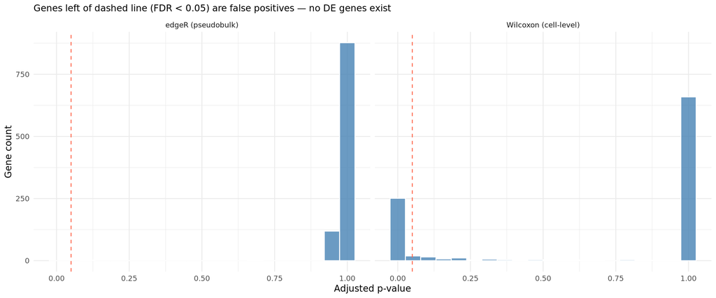

```r
pb_null = sapply(unique(sim_null$metadata$replicate), function(b) {
    rowSums(sim_null$counts[, sim_null$metadata$replicate == b, drop = FALSE])
})
pb_meta_null = sim_null$metadata[match(unique(sim_null$metadata$replicate), sim_null$metadata$replicate), ]
rownames(pb_meta_null) = pb_meta_null$replicate
dge_null = edgeR::DGEList(counts = pb_null, samples = pb_meta_null)
dge_null = edgeR::calcNormFactors(dge_null)
design_null = model.matrix(~ label, data = dge_null$samples)
dge_null = edgeR::estimateDisp(dge_null, design_null)
edger_null_res = edgeR::topTags(
    edgeR::glmLRT(edgeR::glmFit(dge_null, design_null)), n = Inf
)$table

# Align edgeR FDR values to Wilcoxon gene order
edger_fdr_null = edger_null_res$FDR[match(names(padj_null), rownames(edger_null_res))]

fdr_df = data.frame(
    fdr = c(padj_null, edger_fdr_null),
    method = rep(c("Wilcoxon (cell-level)", "edgeR (pseudobulk)"), each = length(padj_null))
)
ggplot(fdr_df, aes(x = fdr)) +
    geom_histogram(bins = 20, fill = "steelblue", colour = "white", alpha = 0.8) +
    geom_vline(xintercept = 0.05, linetype = "dashed", colour = "tomato") +
    facet_wrap(~ method) +
    labs(x = "Adjusted p-value", y = "Gene count",
         subtitle = "Genes left of dashed line (FDR < 0.05) are false positives — no DE genes exist") +
    theme_minimal()
```

```r
cat("Wilcoxon false discoveries:", sum(padj_null < 0.05, na.rm = TRUE), "/ 1000 genes\n")
```

```
Wilcoxon false discoveries: 261 / 1000 genes
```

```r
cat("edgeR false discoveries:  ", sum(edger_fdr_null < 0.05, na.rm = TRUE), "/ 1000 genes\n")
```

```
edgeR false discoveries:   0 / 1000 genes
```

**Interpret:** Which method produces more false discoveries? If Wilcoxon inflates FDR here, what does it tell you about using it on real data?

## 5. Simulation experiment 2 — gene ranking quality (AUPRC)

Controlling FDR is necessary but not sufficient. We also care about **ranking**: does the method place true DE genes near the top of the list? Area under the precision-recall curve (AUPRC) measures this. We already have Wilcoxon results for `sim_de` (`padj_de`); now run edgeR pseudobulk on the same data.

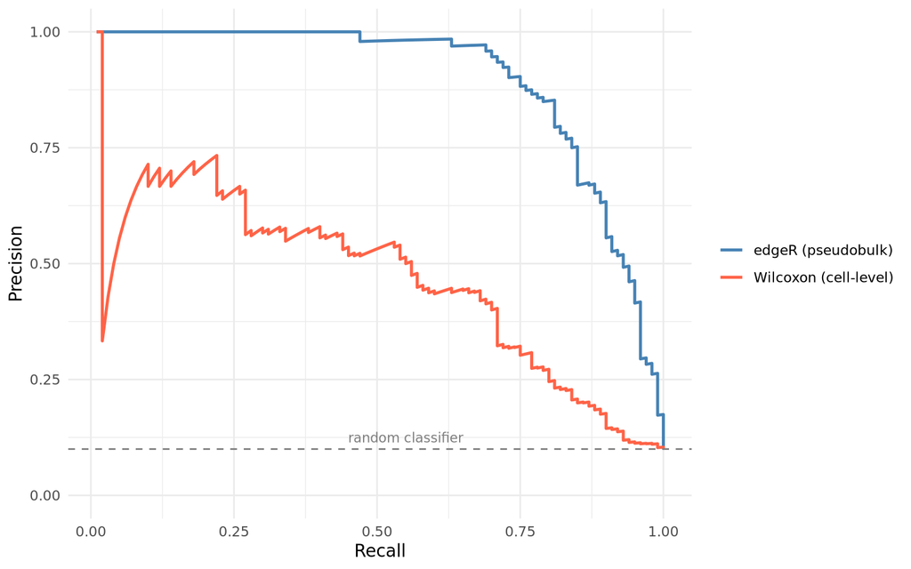

```r
pb_de = sapply(unique(sim_de$metadata$replicate), function(b) {
    rowSums(sim_de$counts[, sim_de$metadata$replicate == b, drop = FALSE])
})
pb_meta_de = sim_de$metadata[match(unique(sim_de$metadata$replicate), sim_de$metadata$replicate), ]
rownames(pb_meta_de) = pb_meta_de$replicate
dge_de = edgeR::DGEList(counts = pb_de, samples = pb_meta_de)
dge_de = edgeR::calcNormFactors(dge_de)
design_de = model.matrix(~ label, data = dge_de$samples)
dge_de = edgeR::estimateDisp(dge_de, design_de)
edger_de_res = edgeR::topTags(
    edgeR::glmLRT(edgeR::glmFit(dge_de, design_de)), n = Inf
)$table
edger_de_res$is_de = rownames(edger_de_res) %in% sim_de$de_genes

wilcox_de_res = data.frame(
    fdr = padj_de,
    is_de = names(padj_de) %in% sim_de$de_genes
)

prc_edger = compute_prc(-log10(edger_de_res$FDR + 1e-300), as.integer(edger_de_res$is_de))
prc_wilcox = compute_prc(-log10(wilcox_de_res$fdr + 1e-300), as.integer(wilcox_de_res$is_de))

prc_df = rbind(
    cbind(prc_edger, method = "edgeR (pseudobulk)"),
    cbind(prc_wilcox, method = "Wilcoxon (cell-level)")
)
baseline = mean(edger_de_res$is_de)

ggplot(prc_df, aes(x = recall, y = precision, colour = method)) +
    geom_line(linewidth = 0.9) +
    geom_hline(yintercept = baseline, linetype = "dashed", colour = "grey50") +
    annotate("text", x = 0.55, y = baseline + 0.025, label = "random classifier", size = 3, colour = "grey50") +
    scale_colour_manual(values = c("steelblue", "tomato")) +
    coord_cartesian(ylim = c(0, 1)) +
    labs(x = "Recall", y = "Precision", colour = NULL) +
    theme_minimal()
```

```r
cat("edgeR AUPRC:", round(auprc(prc_edger), 3), "\n")
```

```
edgeR AUPRC: 0.897
```

```r
cat("Wilcoxon AUPRC:", round(auprc(prc_wilcox), 3), "\n")
```

```
Wilcoxon AUPRC: 0.468
```

```r
cat("Baseline (random):", round(baseline, 3), "\n")
```

```
Baseline (random): 0.1
```

**Interpret:** Which method better separates true DE genes from nulls in its ranking? What does it mean if a method has a high AUPRC but poor FDR control (or vice versa)?

## 6. Simulation experiment 3 — why biological replicates matter

Wilcoxon ignores which cells came from which animal — it treats every cell as an independent observation. Pseudobulk respects the replicate structure by aggregating first. To show why this matters, we can break that structure on purpose: shuffle the replicate labels within each condition so that pseudobulk now gets random cell mixtures instead of real biological replicates. We reuse `sim_de` from section 2.

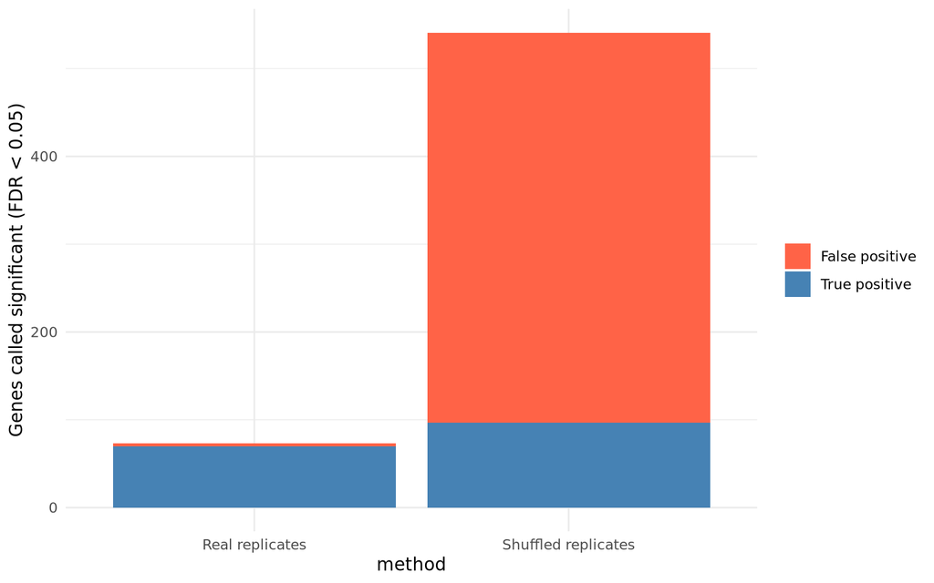

```r
set.seed(42)
shuffled_meta = sim_de$metadata
for (grp in unique(shuffled_meta$label)) {
    idx = which(shuffled_meta$label == grp)
    shuffled_meta$replicate[idx] = sample(shuffled_meta$replicate[idx])
}

pb_shuf = sapply(unique(shuffled_meta$replicate), function(b) {
    rowSums(sim_de$counts[, shuffled_meta$replicate == b, drop = FALSE])
})
pb_meta_shuf = shuffled_meta[match(unique(shuffled_meta$replicate), shuffled_meta$replicate), ]
rownames(pb_meta_shuf) = pb_meta_shuf$replicate
dge_shuf = edgeR::DGEList(counts = pb_shuf, samples = pb_meta_shuf)
dge_shuf = edgeR::calcNormFactors(dge_shuf)
design_shuf = model.matrix(~ label, data = dge_shuf$samples)
dge_shuf = edgeR::estimateDisp(dge_shuf, design_shuf)
edger_shuf_res = edgeR::topTags(
    edgeR::glmLRT(edgeR::glmFit(dge_shuf, design_shuf)), n = Inf
)$table
edger_shuf_res$is_de = rownames(edger_shuf_res) %in% sim_de$de_genes

# edger_de_res from section 5 is the real-replicates result
real_sig = rownames(edger_de_res)[edger_de_res$FDR < 0.05]
shuf_sig = rownames(edger_shuf_res)[edger_shuf_res$FDR < 0.05]

compare_df = data.frame(
    method = rep(c("Real replicates", "Shuffled replicates"), each = 2),
    type = factor(
        rep(c("True positive", "False positive"), 2),
        levels = c("False positive", "True positive")
    ),
    n = c(
        sum(real_sig %in% sim_de$de_genes), sum(!real_sig %in% sim_de$de_genes),
        sum(shuf_sig %in% sim_de$de_genes), sum(!shuf_sig %in% sim_de$de_genes)
    )
)

ggplot(compare_df, aes(x = method, y = n, fill = type)) +
    geom_col() +
    scale_fill_manual(values = c("tomato", "steelblue")) +
    labs(y = "Genes called significant (FDR < 0.05)", fill = NULL) +
    theme_minimal()
```

```r
cat("Real replicates    — sig:", length(real_sig),
    "  TP:", sum(real_sig %in% sim_de$de_genes),
    "  FP:", sum(!real_sig %in% sim_de$de_genes), "\n")
```

```
Real replicates    — sig: 73   TP: 70   FP: 3
```

```r
cat("Shuffled replicates— sig:", length(shuf_sig),
    "  TP:", sum(shuf_sig %in% sim_de$de_genes),
    "  FP:", sum(!shuf_sig %in% sim_de$de_genes), "\n")
```

```
Shuffled replicates— sig: 541   TP: 97   FP: 444
```

```r
cat("True DE genes:", length(sim_de$de_genes), "\n")
```

```
True DE genes: 100
```

**Interpret:** What happens to the number of significant genes when replicate labels are shuffled? Why can’t you recover statistical power by simply splitting cells into more artificial replicates?

Shuffling destroys the between-replicate variance estimate — edgeR sees artificially low dispersion and calls too many genes significant. Creating artificial replicates by splitting cells does not help because the cells still come from the same biological sample; you are not adding new independent observations. The variance estimate needs to reflect real biological replication across animals, not the number of cells per replicate.

## 7. Pseudobulk DE on real SCI data

`Libra::run_de` runs pseudobulk edgeR per cell type. We run all three pairwise comparisons across all cell types and collect results into a single data frame with a `comparison` column.

```r
# Cell type sizes across all conditions
sort(table(sci_sub$cell_type), decreasing = TRUE)
```

```
         Mature oligodendrocytes (MOL)                                 Dorsal
                                 21426                                   9123
               Peripheral immune cells                              Microglia
                                  7012                                   5398
                               Ventral                         Vascular cells
                                  4600                                   4197
  Newly formed oligodendrocytes (NFOL) Oligodendrocytes precursor cells (OPC)
                                  3489                                   3119
                            Astrocytes             Vascular endothelial cells
                                  2368                                   1129
                       Ependymal cells
                                   531
```

```r
comparisons = list(
    "young_vs_uninjured" = c("young", "uninjured"),
    "young_vs_old" = c("young", "old"),
    "uninjured_vs_old" = c("uninjured", "old")
)

de_res = lapply(setNames(names(comparisons), names(comparisons)), function(comp) {
    conds = comparisons[[comp]]
    sub = sci_sub[, sci_sub$label %in% conds]
    res = Libra::run_de(sub, cell_type_col = "cell_type", label_col = "label", replicate_col = "replicate")
    res$sig = res$p_val_adj < 0.05 & abs(res$avg_logFC) > 1
    res
})
```

```
[1] "Astrocytes"
[1] "Dorsal"
[1] "Ependymal cells"
[1] "Mature oligodendrocytes (MOL)"
[1] "Microglia"
[1] "Newly formed oligodendrocytes (NFOL)"
[1] "Oligodendrocytes precursor cells (OPC)"
[1] "Peripheral immune cells"
[1] "Vascular cells"
[1] "Vascular endothelial cells"
[1] "Ventral"
[1] "Astrocytes"
[1] "Dorsal"
[1] "Ependymal cells"
[1] "Mature oligodendrocytes (MOL)"
```

[output cut: 18 more lines]

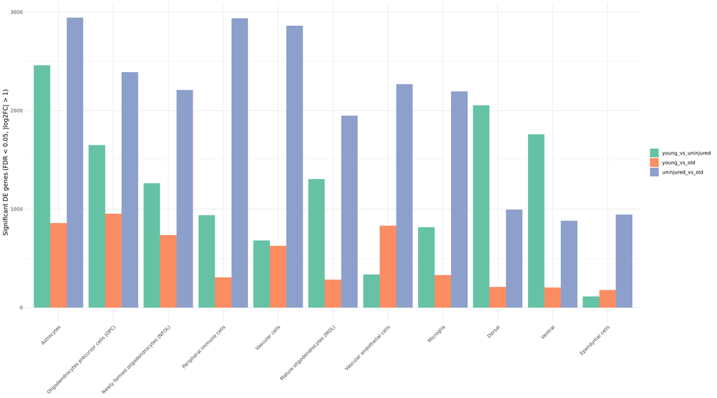

```r
# Sig gene counts per cell type × comparison
sig_counts = do.call(rbind, lapply(names(de_res), function(comp) {
    agg = aggregate(sig ~ cell_type, data = de_res[[comp]], FUN = sum)
    agg$comparison = comp
    agg
}))
sig_counts$comparison = factor(sig_counts$comparison, levels = names(comparisons))

ggplot(sig_counts, aes(x = reorder(cell_type, -sig), y = sig, fill = comparison)) +
    geom_col(position = "dodge") +
    scale_fill_brewer(palette = "Set2") +
    labs(x = NULL, y = "Significant DE genes (FDR < 0.05, |log2FC| > 1)", fill = NULL) +
    theme_minimal() +
    theme(axis.text.x = element_text(angle = 45, hjust = 1))
```

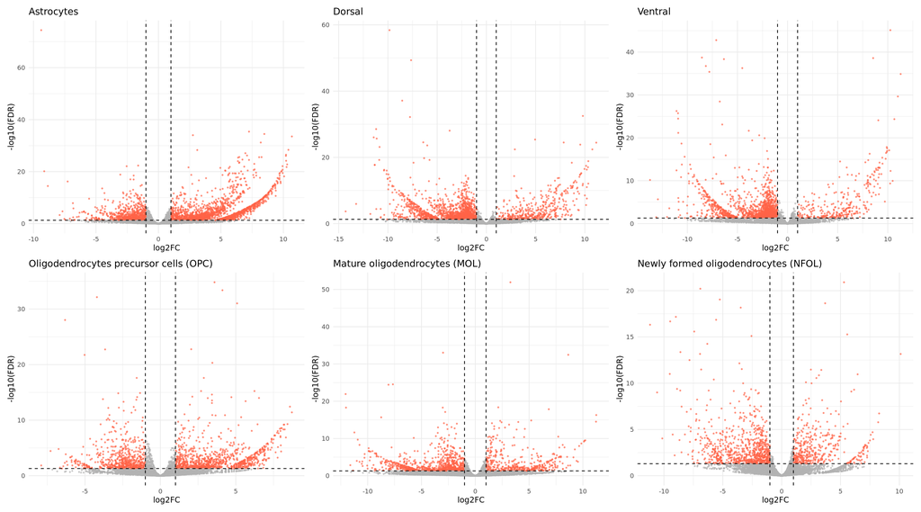

```r
# Volcano plots for young_vs_uninjured — top 6 cell types by sig gene count
yvu = sig_counts[sig_counts$comparison == "young_vs_uninjured", ]
top_cts = head(yvu$cell_type[order(-yvu$sig)], 6)

plots = lapply(top_cts, function(ct) {
    df = de_res[["young_vs_uninjured"]]
    df = df[df$cell_type == ct, ]
    ggplot(df, aes(x = avg_logFC, y = -log10(p_val_adj), colour = sig)) +
        geom_point(alpha = 0.6, size = 0.6) +
        scale_colour_manual(values = c("grey70", "tomato")) +
        geom_vline(xintercept = c(-1, 1), linetype = "dashed") +
        geom_hline(yintercept = -log10(0.05), linetype = "dashed") +
        labs(title = ct, x = "log2FC", y = "-log10(FDR)") +
        theme_minimal() +
        theme(legend.position = "none")
})
patchwork::wrap_plots(plots, ncol = 3)
```

```r
# Top hits for most perturbed cell type (young vs uninjured)
top_ct = top_cts[1]
cat("\n--- Top hits:", top_ct, "(young vs uninjured) ---\n")
```

```
--- Top hits: Astrocytes (young vs uninjured) ---
```

```r
df = de_res[["young_vs_uninjured"]]
df = df[df$cell_type == top_ct & df$sig, ]
print(head(df[order(-abs(df$avg_logFC)), c("gene", "avg_logFC", "p_val_adj")], 10))
```

```
# A tibble: 10 × 3
   gene   avg_logFC p_val_adj
   <chr>      <dbl>     <dbl>
 1 Rpl37      10.7   2.90e-34
 2 Chgb       10.4   4.08e-29
 3 Rpl14      10.3   1.63e-23
 4 Ubb        10.3   1.64e-22
 5 Rps7       10.2   6.58e-25
 6 Ndufa4     10.2   3.02e-27
 7 Cox4i1     10.2   8.45e-27
 8 Stmn1      10.1   6.55e-19
 9 Cox7a2      9.95  3.43e-20
10 Rpl27       9.93  1.76e-21
```

**Explore:** Which cell types respond most strongly to injury? Do the same cell types rank highly across all three comparisons, or does the pattern differ between young and old injury?

**Explore:** Which cell type shows the most DE genes across all three comparisons (young vs uninjured, young vs old, uninjured vs old)? Is the response cell-type-specific or broadly shared? What does this pattern tell you about the injury response relative to aging?

## 7b. Wilcoxon vs pseudobulk — Microglia

We already ran Wilcoxon on Microglia in section 1 (`markers_wilcox`). Pseudobulk edgeR is now in `de_res`. How different are the two gene lists?

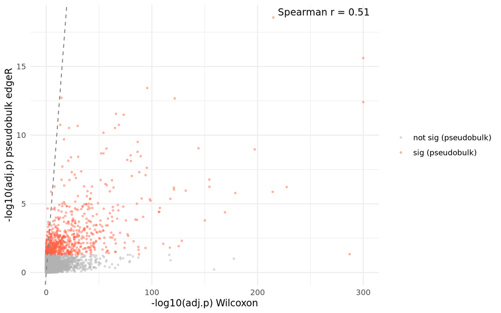

```r
mg_pb = de_res[["young_vs_uninjured"]]
mg_pb = mg_pb[mg_pb$cell_type == "Microglia", ]

# Align on shared genes
shared = intersect(mg_pb$gene, markers_wilcox$gene)
pb_shared = mg_pb[match(shared, mg_pb$gene), ]
wil_shared = markers_wilcox[match(shared, markers_wilcox$gene), ]

# p-value correlation
pval_df = data.frame(
    nlp_wilcox = -log10(pmax(wil_shared$p_val_adj, 1e-300)),
    nlp_pb = -log10(pmax(pb_shared$p_val_adj, 1e-300)),
    pb_sig = pb_shared$p_val_adj < 0.05
)
r = round(cor(pval_df$nlp_wilcox, pval_df$nlp_pb, method = "spearman"), 2)

ggplot(pval_df, aes(x = nlp_wilcox, y = nlp_pb)) +
    geom_point(aes(colour = pb_sig), alpha = 0.4, size = 0.7) +
    geom_abline(linetype = "dashed", colour = "grey50") +
    scale_colour_manual(values = c("grey70", "tomato"),
                        labels = c("not sig (pseudobulk)", "sig (pseudobulk)")) +
    annotate("text", x = Inf, y = Inf, hjust = 1.1, vjust = 1.5,
             label = paste("Spearman r =", r)) +
    labs(x = "-log10(adj.p) Wilcoxon", y = "-log10(adj.p) pseudobulk edgeR",
         colour = NULL) +
    theme_minimal()
```

```r
# Count comparison
wilcox_sig = markers_wilcox$gene[markers_wilcox$p_val_adj < 0.05 & abs(markers_wilcox$avg_log2FC) > 1]
pb_sig = mg_pb$gene[mg_pb$p_val_adj < 0.05 & abs(mg_pb$avg_logFC) > 1]

cat("Wilcoxon significant genes:", length(wilcox_sig), "\n")
```

```
Wilcoxon significant genes: 2262
```

```r
cat("Pseudobulk significant genes:", length(pb_sig), "\n")
```

```
Pseudobulk significant genes: 816
```

```r
cat("Overlap:", length(intersect(wilcox_sig, pb_sig)), "\n")
```

```
Overlap: 728
```

```r
cat("Wilcoxon-only (likely false positives):", length(setdiff(wilcox_sig, pb_sig)), "\n")
```

```
Wilcoxon-only (likely false positives): 1534
```

```r
cat("Pseudobulk-only (missed by Wilcoxon):", length(setdiff(pb_sig, wilcox_sig)), "\n")
```

```
Pseudobulk-only (missed by Wilcoxon): 88
```

**Interpret:** Do the two methods agree on fold change direction? Where do they diverge — is it mostly Wilcoxon calling extra genes, or are there genes pseudobulk finds that Wilcoxon misses?

## 8. GO enrichment

Build the GO BP gene sets from `org.Mm.eg.db` once, then pass them directly to `enricher` and `GSEA` — this avoids re-querying the database on every call.

```r
go_ann = AnnotationDbi::select(
    org.Mm.eg.db,
    keys = keys(org.Mm.eg.db, "SYMBOL"),
    columns = c("SYMBOL", "GO", "ONTOLOGY"),
    keytype = "SYMBOL"
)
go_ann = go_ann[!is.na(go_ann$GO) & go_ann$ONTOLOGY == "BP", ]

go_t2g = unique(go_ann[, c("GO", "SYMBOL")])
go_t2n = unique(AnnotationDbi::select(
    GO.db::GO.db, keys = unique(go_t2g$GO), columns = "TERM", keytype = "GOID"
)[, c("GOID", "TERM")])
names(go_t2g) = c("term", "gene")
names(go_t2n) = c("term", "name")
```

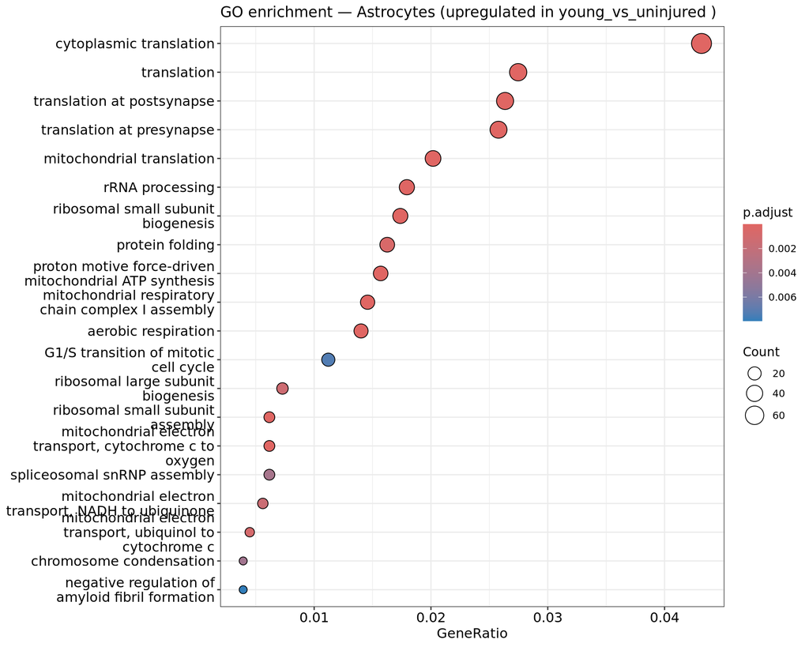

```r
ct_for_go = top_cts[1]
comp_for_go = "young_vs_uninjured"
de_go = de_res[[comp_for_go]][de_res[[comp_for_go]]$cell_type == ct_for_go, ]
sig_genes = de_go$gene[de_go$p_val_adj < 0.05 & de_go$avg_logFC > 0]

ego = enricher(
    gene = sig_genes,
    universe = de_go$gene,
    TERM2GENE = go_t2g,
    TERM2NAME = go_t2n,
    pAdjustMethod = "BH"
)

dotplot(ego, showCategory = 20) +
    labs(title = paste("GO enrichment —", ct_for_go, "(upregulated in", comp_for_go, ")"))
```

**Explore:** What biological processes come up? Do they match your expectations for this cell type after injury?

## 9. GSEA

GO ORA only uses genes that pass a threshold. GSEA uses the **full ranked list** — every gene gets a fold change score, and the algorithm asks whether genes in a pathway cluster near the top or bottom. This is more sensitive and doesn’t require an arbitrary cutoff.

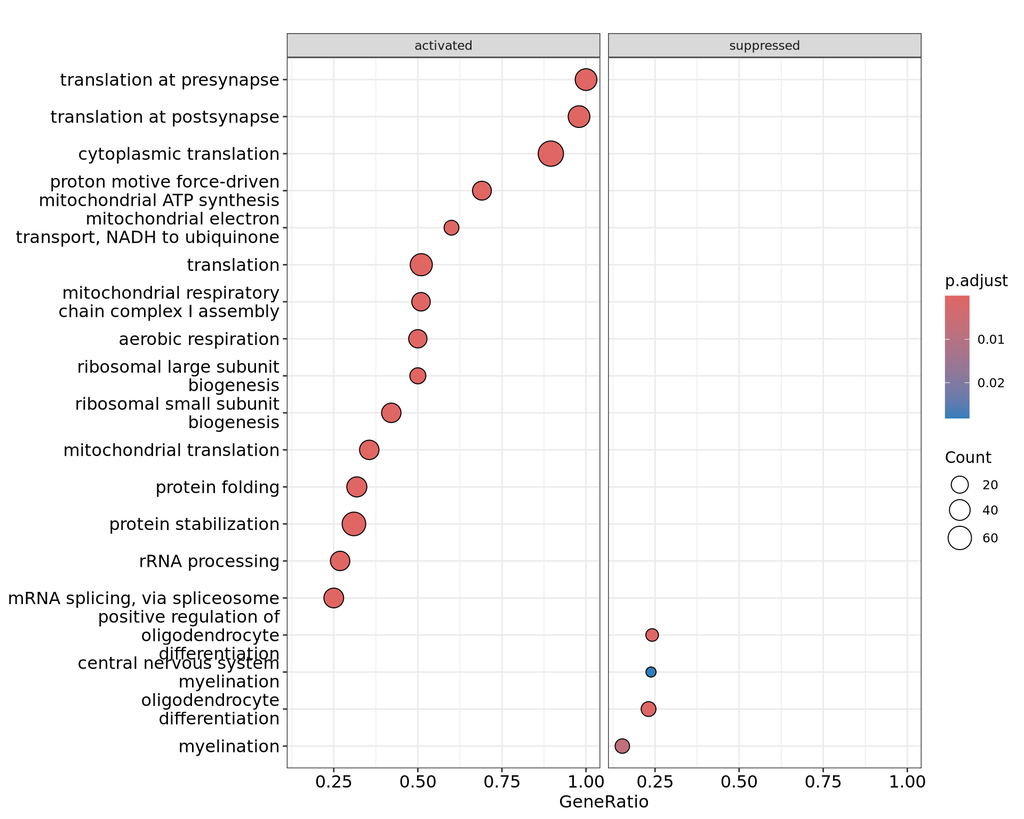

```r
ct_for_gsea = top_cts[1]
comp_for_gsea = "young_vs_uninjured"
de_ct = de_res[[comp_for_gsea]][de_res[[comp_for_gsea]]$cell_type == ct_for_gsea, ]
gene_list = sort(setNames(de_ct$avg_logFC, de_ct$gene), decreasing = TRUE)

gsea_res = GSEA(
    geneList = gene_list,
    TERM2GENE = go_t2g,
    TERM2NAME = go_t2n,
    minGSSize = 15,
    maxGSSize = 500,
    pAdjustMethod = "BH",
    verbose = FALSE
)
dotplot(gsea_res, showCategory = 15, split = ".sign") +
    facet_grid(. ~ .sign)
```

**Explore:** Do the GSEA results agree with GO? Are there pathways that GSEA picks up that ORA missed, or vice versa? What does the direction (activated vs suppressed) tell you about the biology?

**Explore:** Pick one enriched GO term from your results. Look up 2–3 of the genes driving it. Are any already known SCI or neuroinflammation markers? Does the unbiased GO analysis confirm or surprise you?

## 10. Custom gene sets — module scores

GO and GSEA test pre-defined databases of gene sets. Often you instead have a **custom gene panel** from a specific paper — a signature that isn’t in GO/MSigDB at all. Seurat’s `AddModuleScore` lets you score every cell for such a panel directly: for each cell, it computes the average expression of the panel genes minus the average expression of a control gene set (randomly sampled, matched for expression level), giving one number per cell instead of a per-gene test.

As an example, we use the **blood–brain barrier (BBB) dysfunction module** from Munji et al. (2019, *Nat Neurosci*) — a set of genes consistently induced in vascular endothelial cells across seven different CNS injury/disease models when the BBB breaks down.

```r
bbb_genes = c(
    "Acot7", "Adam12", "Adam19", "Adamts4", "Adamts8", "Aebp1", "Aldh18a1", "Aldh1a2", "Anln", "Anxa1",
    "Apln", "Aplnr", "Aprt", "Aspm", "Atp8b1", "B3gnt3", "Bicc1", "Bmp1", "Bub1b", "Cip2a",
    "Casp4", "Ccl2", "Ccna2", "Ccnb2", "Cd14", "Cd44", "Cdk1", "Cenpe", "Cenpf", "Ch25h",
    "Chst1", "Ckap2", "Cks1b", "Cmtm3", "Col12a1", "Col1a1", "Col1a2", "Col3a1", "Col5a1", "Col5a2",
    "Cxcl10", "Cyp1b1", "D17H6S56E-5", "Ackr1", "Dcn", "Dkk3", "Dpysl3", "Emilin1", "Fblim1", "Fbln1",
    "Fbn1", "Fkbp10", "Flnc", "Frrs1", "Fscn1", "Gjb2", "Gm6169", "Hmmr", "Ifitm1", "Igfbp4",
    "Igfbp5", "Igsf10", "Islr", "Itgb3", "Kif11", "Kif15", "Kif20b", "Kit", "Lamb1", "Lbp",
    "Lcp2", "Lgals1", "Lgmn", "Lox", "Loxl2", "Loxl3", "Lrg1", "Lum", "Marcksl1", "Mcm5",
    "Meox1", "Mki67", "Mmp14", "Myc", "Ndc80", "Nfil3", "Nt5dc2", "Parp3", "Pdlim1", "Pgf",
    "Plekho1", "Plekho2", "Postn", "Prc1", "Ptgfrn", "Ptgs2", "Nectin2", "Pxdn", "Robo1", "Rrm2",
    "Runx1", "S100a6", "Scgb3a1", "Sele", "Selp", "Serpine1", "Serping1", "Slc16a6", "Slc43a3", "Slc7a11",
    "Slc7a7", "Slfn9", "Spp1", "Sulf1", "Sulf2", "Synpo", "Tacc3", "Thbs1", "Thbs2", "Thy1",
    "Timp1", "Tlr2", "Sting1", "Tmem176a", "Tnc", "Tnfrsf23", "Tnfsf8", "Top2a", "Tpx2", "Trp53i11",
    "Tubb6", "Ube2c", "Upp1", "Vcan", "Vwf", "Zfp521"
)

vec = sci_sub[, sci_sub$cell_type == "Vascular endothelial cells"]
vec = NormalizeData(vec, verbose = FALSE)

bbb_present = intersect(bbb_genes, rownames(vec))
cat(length(bbb_present), "/", length(bbb_genes), "BBB dysfunction genes found in the dataset\n")
```

```
135 / 136 BBB dysfunction genes found in the dataset
```

```r
vec = AddModuleScore(vec, features = list(bbb_present), name = "BBB_dysfunction")
vec_meta = vec@meta.data
vec_meta$label = factor(vec_meta$label, levels = c("uninjured", "young", "old"))
```

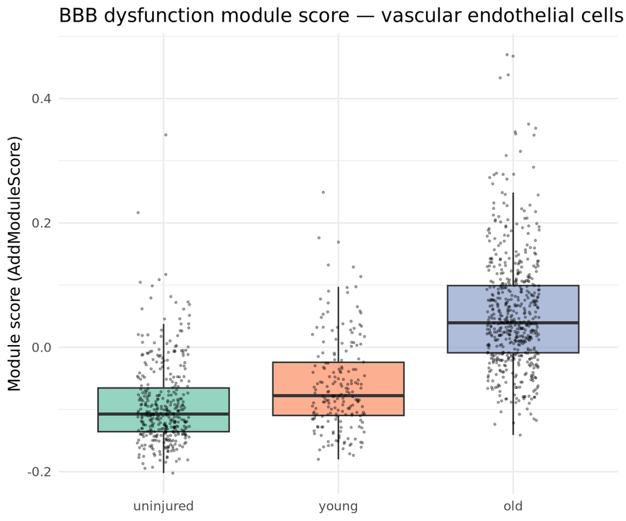

```r
ggplot(vec_meta, aes(x = label, y = BBB_dysfunction1, fill = label)) +
    geom_boxplot(outlier.shape = NA, alpha = 0.7) +
    geom_jitter(width = 0.15, size = 0.4, alpha = 0.3) +
    scale_fill_brewer(palette = "Set2") +
    labs(
        title = "BBB dysfunction module score — vascular endothelial cells",
        x = NULL, y = "Module score (AddModuleScore)"
    ) +
    theme_minimal() +
    theme(legend.position = "none")
```

**Interpret:** Does the BBB dysfunction score look higher in injured (young/old) vs uninjured spinal cord? Is the spread within a condition mostly driven by a few animals, or evenly spread across cells?

Just like in sections 2–6, cells from the same animal are not independent observations — a t-test or Wilcoxon test on cell-level module scores would treat every cell as a fresh data point and produce an overconfident p-value. The fix is the same: a **mixed model** with replicate as a random effect, so the test statistic reflects between-animal variation rather than between-cell variation.

```r
bbb_lmm_res = do.call(rbind, lapply(names(comparisons), function(comp) {
    conds = comparisons[[comp]]
    df = vec_meta[vec_meta$label %in% conds, ]
    df$label = factor(df$label, levels = conds)
    fit = lmerTest::lmer(BBB_dysfunction1 ~ label + (1 | replicate), data = df)
    coefs = summary(fit)$coefficients
    data.frame(
        comparison = comp,
        estimate   = coefs[2, "Estimate"],
        std_error  = coefs[2, "Std. Error"],
        p_value    = coefs[2, "Pr(>|t|)"]
    )
}))
bbb_lmm_res
```

```
          comparison    estimate  std_error      p_value
1 young_vs_uninjured -0.03371333 0.01916106 0.1746843518
2       young_vs_old  0.11713952 0.01613700 0.0062906149
3   uninjured_vs_old  0.15031335 0.01172585 0.0001936556
```

**Explore:** Which comparison(s) show a significant difference in BBB dysfunction score? Does the direction (higher after injury?) match what you’d expect biologically? Would you have reached the same conclusion with a naive t-test on all cells pooled together?

**CHECKPOINT**

Which cell type has the most DE genes? Are the responses cell-type-specific or shared?

- How different are the Wilcoxon hits (section 1) from the pseudobulk hits (section 7)?
- What do GO and GSEA together suggest about what is happening in your chosen cell type after injury?
- Does the BBB dysfunction module score differ across the three comparisons, and does a mixed model change your conclusion relative to a naive cell-level test?

## Challenge: Apply to your own data

Find a publicly available scRNA-seq dataset with **at least two conditions** and **biological replicates**, then apply the pseudobulk DE + GO/GSEA pipeline from this notebook.

A convenient starting point is the **Kang et al. 2018 PBMC IFN-β stimulation** dataset (GEO: GSE96583), available directly through `SeuratData`. It has two conditions (CTRL / STIM) and cell type annotations for all major PBMC populations.

```r
library(SeuratData)
InstallData("ifnb")
LoadData("ifnb")   # loads Seurat object named 'ifnb'

# Rename to match pipeline conventions
ifnb$label     = ifnb$stim                    # "CTRL" or "STIM"
ifnb$cell_type = ifnb$seurat_annotations
# No true biological replicates — add mock IDs for demonstration only
set.seed(42)
ifnb$replicate = sample(c("r1", "r2", "r3"), ncol(ifnb), replace = TRUE)

de_ifnb = lapply(setNames("CTRL_vs_STIM", "CTRL_vs_STIM"), function(comp) {
    sub = ifnb[, ifnb$label %in% c("CTRL", "STIM")]
    res = Libra::run_de(sub,
        cell_type_col = "cell_type",
        label_col     = "label",
        replicate_col = "replicate")
    res$sig = res$p_val_adj < 0.05 & abs(res$avg_logFC) > 1
    res
})
```

### Where else to find data

- **GEO** (`ncbi.nlm.nih.gov/geo`) — search `scRNA-seq [tissue or disease]`
- **CELLxGENE** (`cellxgene.cziscience.com`) — downloadable `.h5ad` files (use `SeuratDisk::Convert`)
- **Zenodo / figshare** — many papers deposit Seurat objects directly